# Visualización de la Información

Oscar Centeno Mora

El presente tema expone la representación visual mediantes gráficos, nube de palabras y otros elementos. Se abordarán los puntos:

- ¿Cuál método visual utilizar?
- Visualización clásica.
- ggplot.
- Plotly.
- sunburstR
- highcharter
- Otras librerías en R….

Al finalizar la sesión podrá conocer los principales **paquetes** - *librerías* de visualización de la información en R.

[figure not shown]

## Formas de visualizar

[figure not shown]

Existen muchas, muchíiiiiiiisimas formas para visualizar la información. ¿Qué deberíamos elegir? Esto depende de lo que queramos hacer.

- Barras verticales / horizontales.
- Histogramas.
- Lineas.
- Áreas.
- Disperción.
- Circular.
- Anillos o donas.
- Proyección solar.
- Bloques.
- Radar.
- Mapas.
- Nube de palabras.
- etc…

Y la lista podría seguir…

Al analizar datos nos hacemos la pregunta: ¿qué debería utlizar para visualr esta información?

Acá les presento una guía resumida:

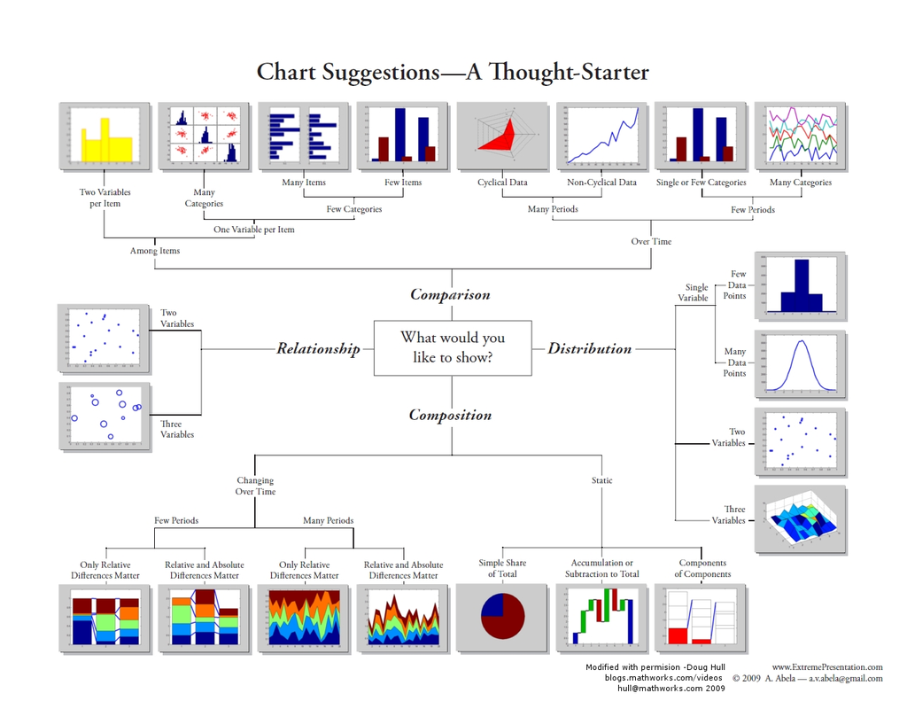

¿Y para visual el texto que utilizamos?

Trataremos de cubrir esta pregunta más adelante, sin embargo adentarse en el mundo de la visualización es descubrir que existe una gama mucho más amplia, versatil e interesante a la hora de visualizar nuestra data.

## Clásico.

[figure not shown]

## lattice

[figure not shown]

## ggplot2

[figure not shown]

La cantidad de gráficos y otros es bastante abundandante. En la página de ggplot2 nos brindan una guia:

- https://www.r-graph-gallery.com/all-graphs.html
- https://www.r-graph-gallery.com/index.html

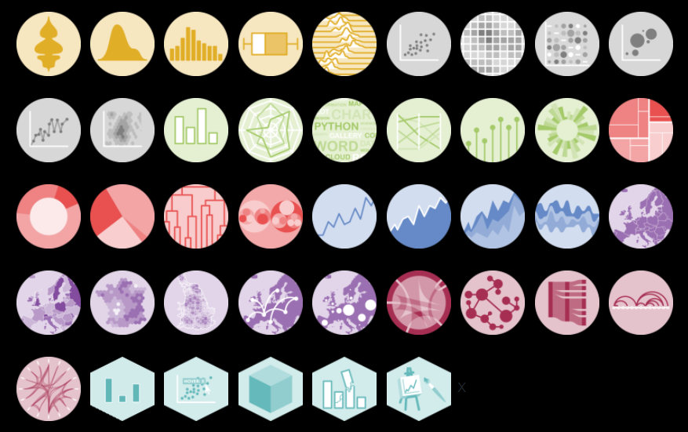

Se suele clasificar en

- Distribución.
- Correlación.
- Ranking.
- “Part of a whole”.
- Tendencia o evolución.
- Mapas.
- Flow.

Veamos algunos tipos

### Distribución

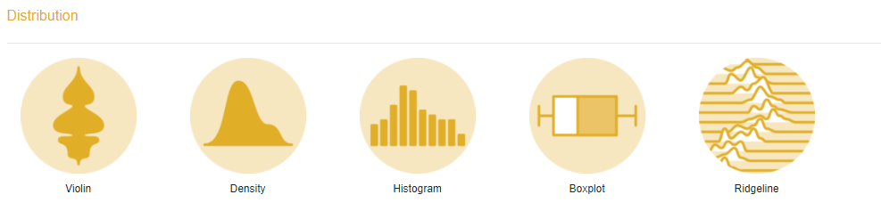

Veamos unos cuantos:

##### Violín

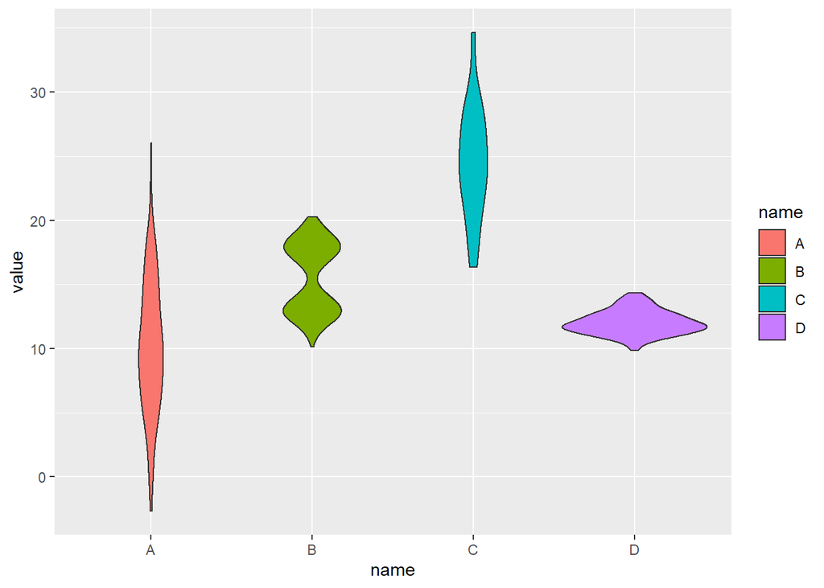

```r
# DAtos
data <- data.frame(
  name=c( rep("A",500), rep("B",500), rep("B",500), rep("C",20), rep('D', 100)  ),
  value=c( rnorm(500, 10, 5), rnorm(500, 13, 1), rnorm(500, 18, 1), rnorm(20, 25, 4), rnorm(100, 12, 1) )
)

# Most basic violin chart
p <- ggplot(data, aes(x=name, y=value, fill=name)) +
  geom_violin()

p
```

##### Densidad doble

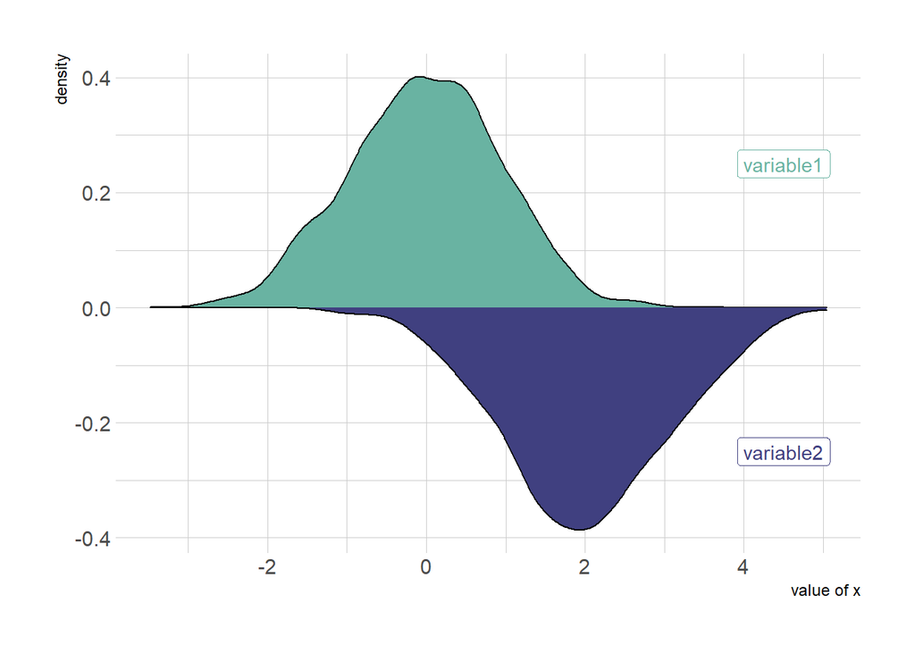

```r
# Dummy data
data <- data.frame(
  var1 = rnorm(1000),
  var2 = rnorm(1000, mean=2)
)

# Chart
p <- ggplot(data, aes(x=x) ) +
  # Top
  geom_density( aes(x = var1, y = ..density..), fill="#69b3a2" ) +
  geom_label( aes(x=4.5, y=0.25, label="variable1"), color="#69b3a2") +
  # Bottom
  geom_density( aes(x = var2, y = -..density..), fill= "#404080") +
  geom_label( aes(x=4.5, y=-0.25, label="variable2"), color="#404080") +
  theme_ipsum() +
  xlab("value of x")

p
```

##### Histograma

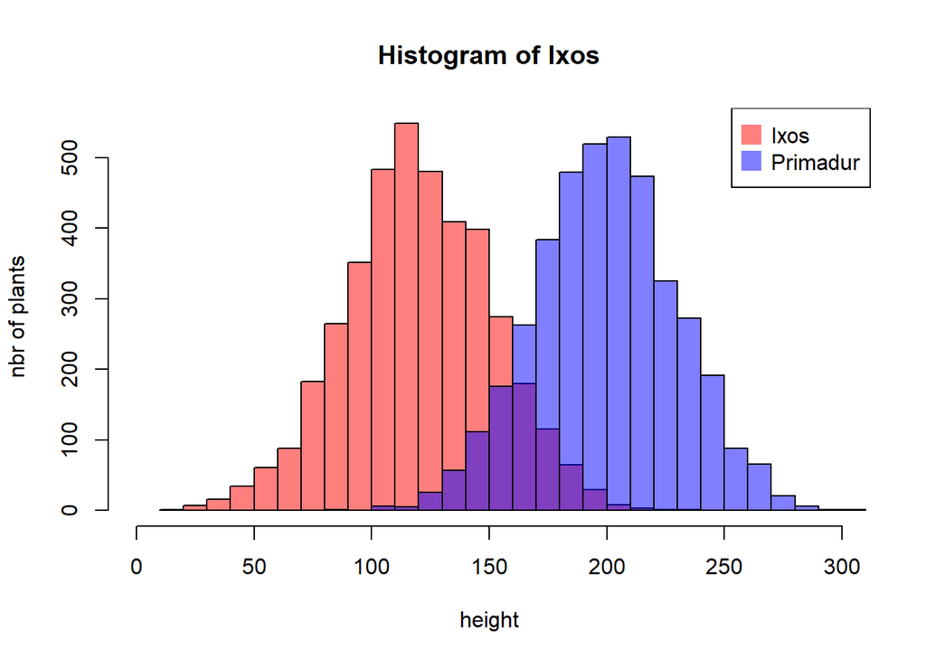

```r
set.seed(1)
Ixos=rnorm(4000 , 120 , 30)
Primadur=rnorm(4000 , 200 , 30)

# First distribution
hist(Ixos, breaks=30, xlim=c(0,300), col=rgb(1,0,0,0.5), xlab="height",
     ylab="nbr of plants" )

# Second with add=T to plot on top
hist(Primadur, breaks=30, xlim=c(0,300), col=rgb(0,0,1,0.5), add=T)

# Add legend
legend("topright", legend=c("Ixos","Primadur"), col=c(rgb(1,0,0,0.5),
     rgb(0,0,1,0.5)), pt.cex=2, pch=15 )
```

#### Boxplot

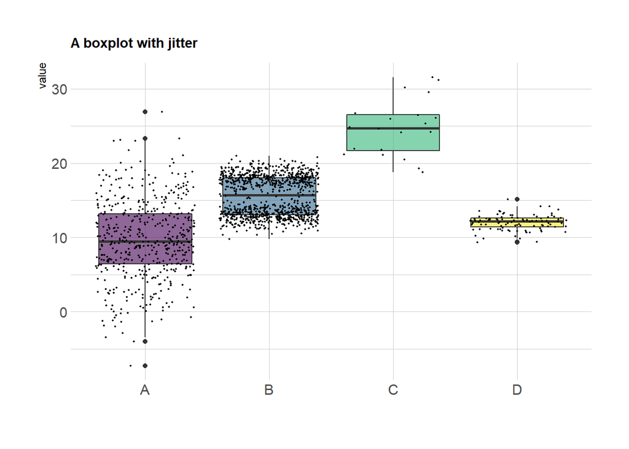

```r
data <- data.frame(
  name=c( rep("A",500), rep("B",500), rep("B",500), rep("C",20), rep('D', 100)  ),
  value=c( rnorm(500, 10, 5), rnorm(500, 13, 1), rnorm(500, 18, 1), rnorm(20, 25, 4), rnorm(100, 12, 1) )
)


data %>%
  ggplot( aes(x=name, y=value, fill=name)) +
    geom_boxplot() +
    scale_fill_viridis(discrete = TRUE, alpha=0.6) +
    geom_jitter(color="black", size=0.4, alpha=0.9) +
    theme_ipsum() +
    theme(
      legend.position="none",
      plot.title = element_text(size=11)
    ) +
    ggtitle("A boxplot with jitter") +
    xlab("")
```

### Correlación

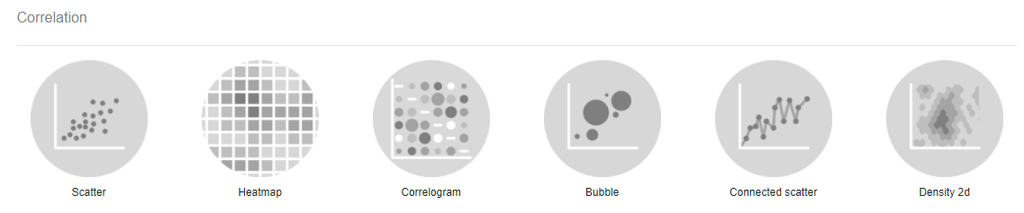

Algunos ejemplos:

##### Disperción

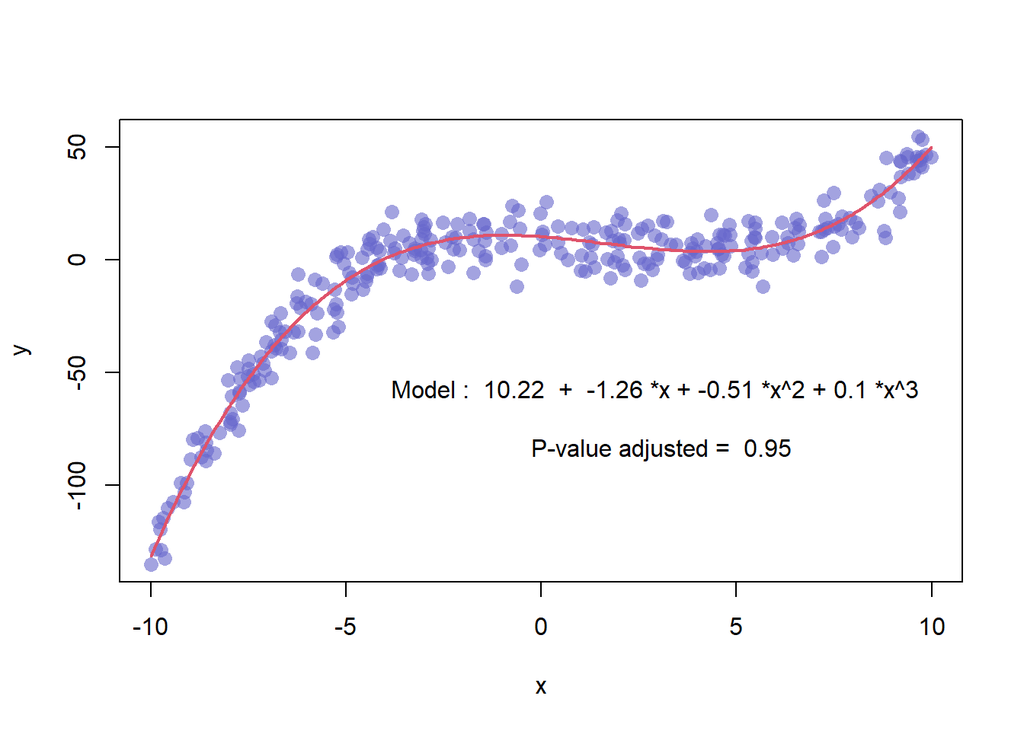

```r
x <- runif(300,  min=-10, max=10)
y <- 0.1*x^3 - 0.5 * x^2 - x + 10 + rnorm(length(x),0,8)

# plot of x and y :
plot(x,y,col=rgb(0.4,0.4,0.8,0.6),pch=16 , cex=1.3)

# Can we find a polynome that fit this function ?
model <- lm(y ~ x + I(x^2) + I(x^3))

# I can get the features of this model :
#summary(model)
#model$coefficients
#summary(model)$adj.r.squared

# For each value of x, I can get the value of y estimated by the model, and add it to the current plot !
myPredict <- predict( model )
ix <- sort(x,index.return=T)$ix
lines(x[ix], myPredict[ix], col=2, lwd=2 )

# I add the features of the model to the plot
coeff <- round(model$coefficients , 2)
text(3, -70 , paste("Model : ",coeff[1] , " + " , coeff[2] , "*x"  , "+" , coeff[3] , "*x^2" , "+" , coeff[4] , "*x^3" , "\n\n" , "P-value adjusted = ",round(summary(model)$adj.r.squared,2)))
```

##### Mapa de calor

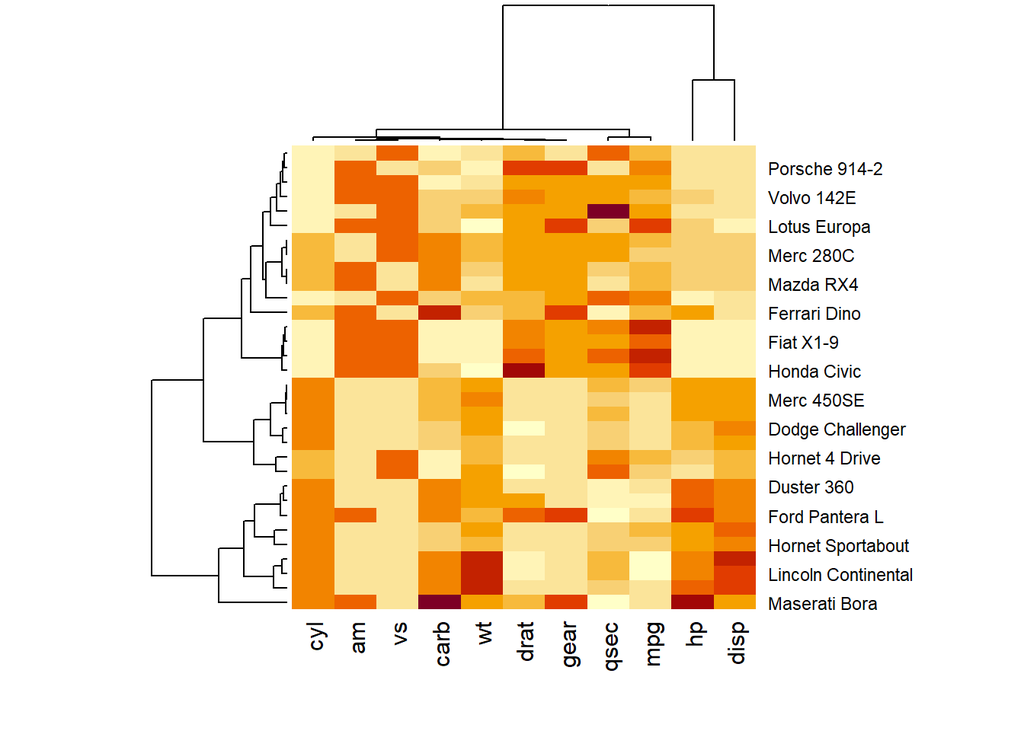

```r
data <- as.matrix(mtcars)

heatmap(data, scale="column")
```

##### Burbujas

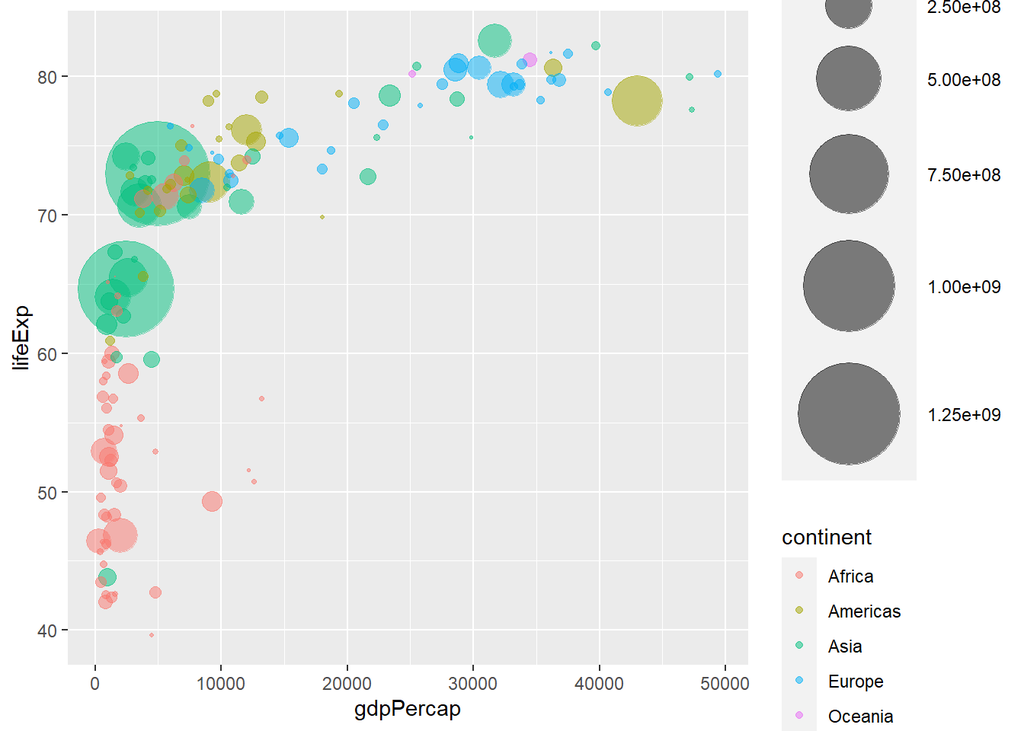

```r
# The dataset is provided in the gapminder library
library(gapminder)
data <- gapminder %>% filter(year=="2007") %>% dplyr::select(-year)

# Most basic bubble plot
data %>%
  arrange(desc(pop)) %>%
  mutate(country = factor(country, country)) %>%
  ggplot(aes(x=gdpPercap, y=lifeExp, size=pop, color=continent)) +
    geom_point(alpha=0.5) +
    scale_size(range = c(.1, 24), name="Population (M)")
```

### Ranking

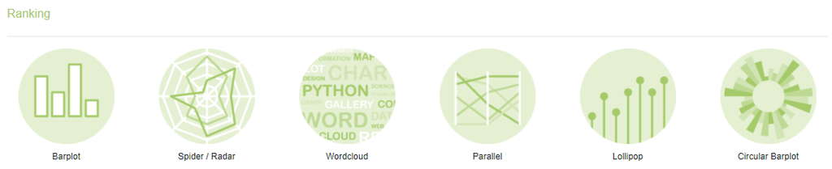

Los ejemplos

##### Radar

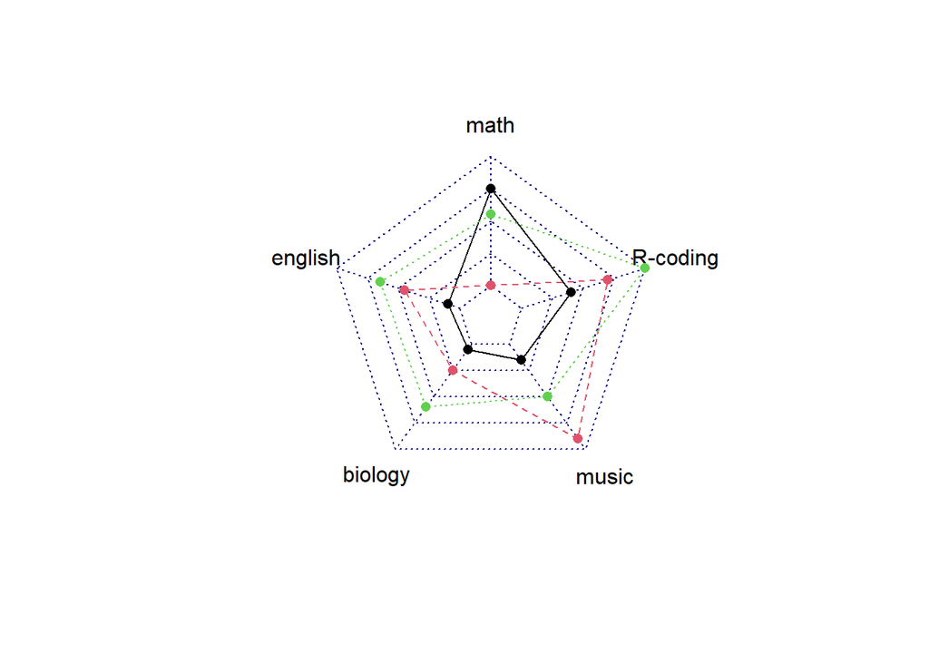

```r
library(fmsb)

# Create data: note in High school for several students
set.seed(99)
data <- as.data.frame(matrix( sample( 0:20 , 15 , replace=F) , ncol=5))
colnames(data) <- c("math" , "english" , "biology" , "music" , "R-coding" )
rownames(data) <- paste("mister" , letters[1:3] , sep="-")

# To use the fmsb package, I have to add 2 lines to the dataframe: the max and min of each variable to show on the plot!
data <- rbind(rep(20,5) , rep(0,5) , data)

# plot with default options:
radarchart(data)
```

##### Gráfico de coordinadas paralelas

```r
library(hrbrthemes)
library(GGally)
```

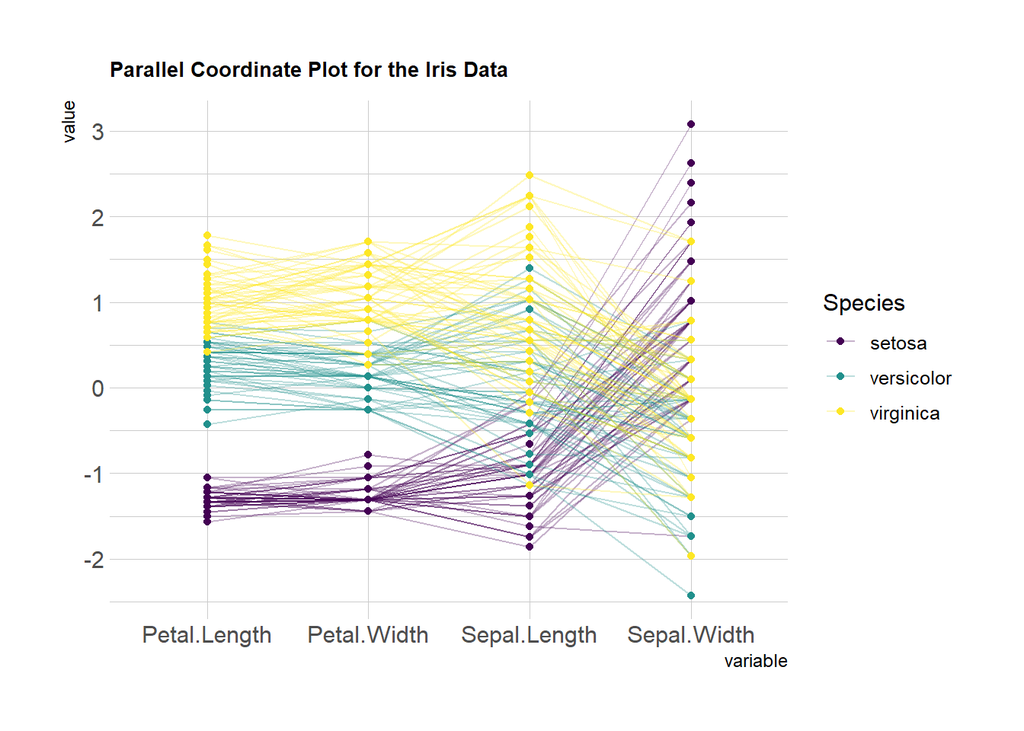

```r
library(viridis)

# Data set is provided by R natively
data <- iris

# Plot
ggparcoord(data,
    columns = 1:4, groupColumn = 5, order = "anyClass",
    showPoints = TRUE,
    title = "Parallel Coordinate Plot for the Iris Data",
    alphaLines = 0.3
    ) +
  scale_color_viridis(discrete=TRUE) +
  theme_ipsum()+
  theme(
    plot.title = element_text(size=10)
  )
```

##### Gráfico de barras circulares

```r
library(tidyverse)
```

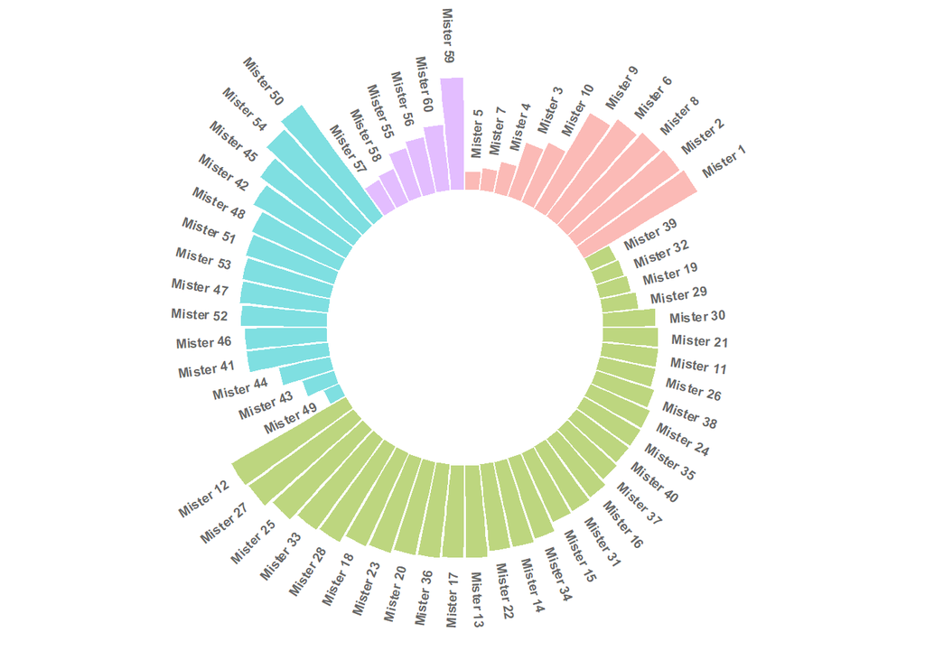

```r
# Create dataset
data <- data.frame(
  individual=paste( "Mister ", seq(1,60), sep=""),
  group=c( rep('A', 10), rep('B', 30), rep('C', 14), rep('D', 6)) ,
  value=sample( seq(10,100), 60, replace=T)
)

data = data %>% arrange(group, value)

# Set a number of 'empty bar' to add at the end of each group
empty_bar <- 4
to_add <- data.frame( matrix(NA, empty_bar*nlevels(data$group), ncol(data)) )
colnames(to_add) <- colnames(data)
to_add$group <- rep(levels(data$group), each=empty_bar)
data <- rbind(data, to_add)
data <- data %>% arrange(group)
data$id <- seq(1, nrow(data))

# Get the name and the y position of each label
label_data <- data
number_of_bar <- nrow(label_data)
angle <- 90 - 360 * (label_data$id-0.5) /number_of_bar     # I substract 0.5 because the letter must have the angle of the center of the bars. Not extreme right(1) or extreme left (0)
label_data$hjust <- ifelse( angle < -90, 1, 0)
label_data$angle <- ifelse(angle < -90, angle+180, angle)

# Make the plot
p <- ggplot(data, aes(x=as.factor(id), y=value, fill=group)) +       # Note that id is a factor. If x is numeric, there is some space between the first bar
  geom_bar(stat="identity", alpha=0.5) +
  ylim(-100,120) +
  theme_minimal() +
  theme(
    legend.position = "none",
    axis.text = element_blank(),
    axis.title = element_blank(),
    panel.grid = element_blank(),
    plot.margin = unit(rep(-1,4), "cm")
  ) +
  coord_polar() +
  geom_text(data=label_data, aes(x=id, y=value+10, label=individual, hjust=hjust), color="black", fontface="bold",alpha=0.6, size=2.5, angle= label_data$angle, inherit.aes = FALSE )

p
```

### “Part of a whole”

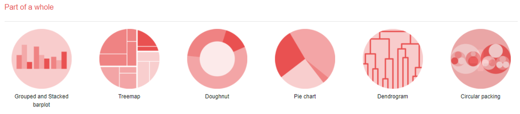

Veamos algunos ejemplos

##### Barras verticales agrupadas

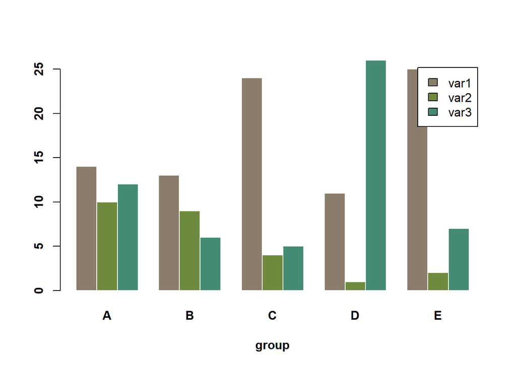

```r
set.seed(112)
data <- matrix(sample(1:30,15) , nrow=3)
colnames(data) <- c("A","B","C","D","E")
rownames(data) <- c("var1","var2","var3")

# Grouped barplot
barplot(data,
        col=colors()[c(23,89,12)] ,
        border="white",
        font.axis=2,
        beside=T,
        legend=rownames(data),
        xlab="group",
        font.lab=2)
```

##### Treemap

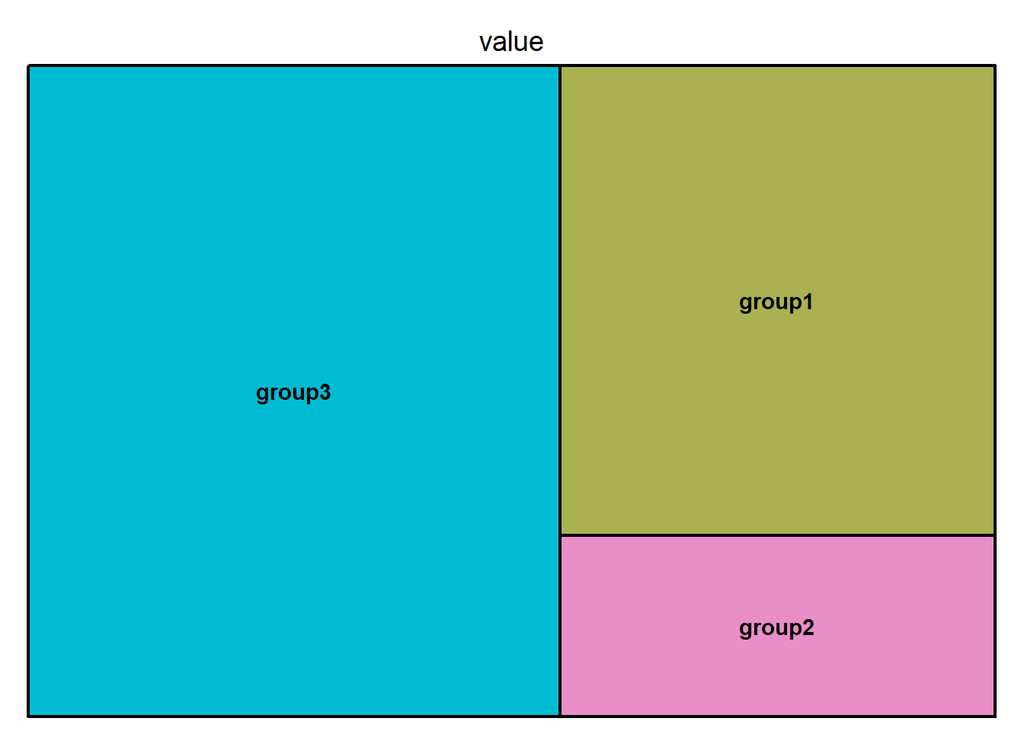

```r
# library
library(treemap)

# Create data
group <- c("group1","group2","group3")
value <- c(13,5,22)
data <- data.frame(group,value)

# treemap
treemap(data,
            index="group",
            vSize="value",
            type="index"
            )
```

##### Dendograma

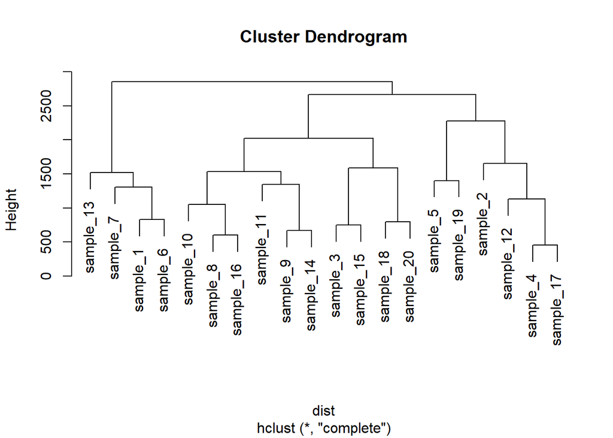

```r
data <- matrix( sample(seq(1,2000),200), ncol = 10 )
rownames(data) <- paste0("sample_" , seq(1,20))
colnames(data) <- paste0("variable",seq(1,10))

# Euclidean distance
dist <- dist(data[ , c(4:8)] , diag=TRUE)

# Hierarchical Clustering with hclust
hc <- hclust(dist)

# Plot the result
plot(hc)
```

### Tendencia o evolución

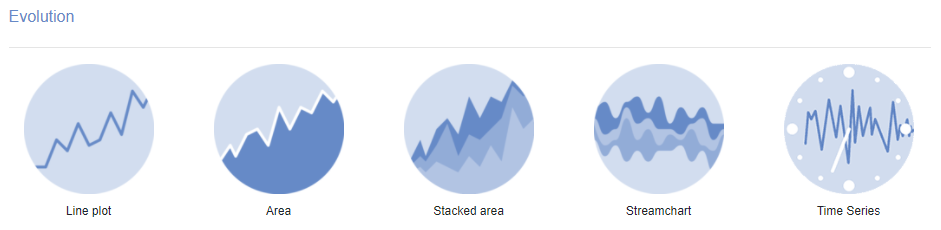

Algunos ejemplos:

##### Área

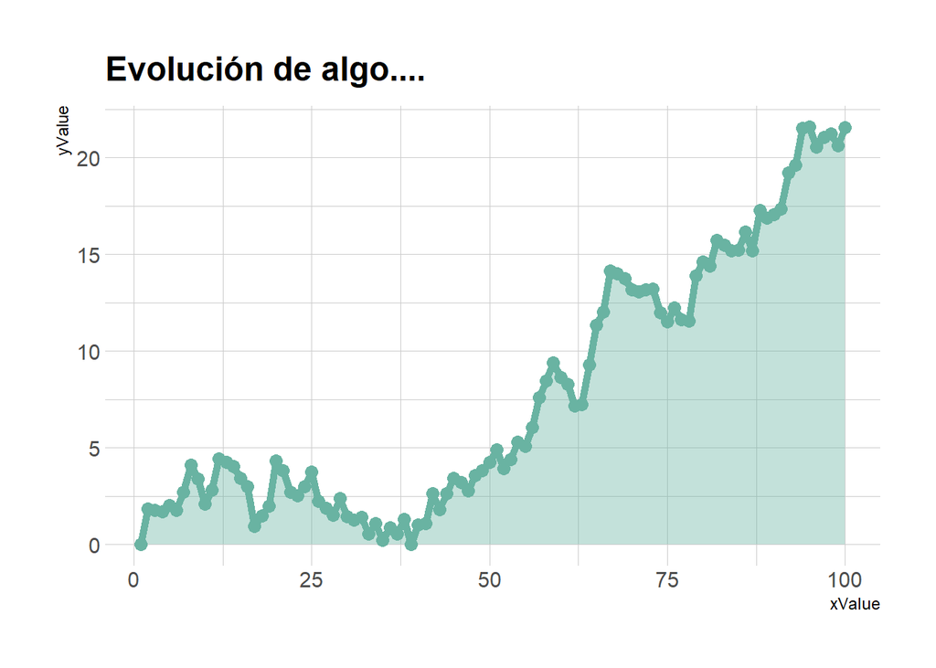

```r
library(ggplot2)
library(hrbrthemes)

# create data
xValue <- 1:100
yValue <- abs(cumsum(rnorm(100)))
data <- data.frame(xValue,yValue)

# Plot
ggplot(data, aes(x=xValue, y=yValue)) +
  geom_area( fill="#69b3a2", alpha=0.4) +
  geom_line(color="#69b3a2", size=2) +
  geom_point(size=3, color="#69b3a2") +
  theme_ipsum() +
  ggtitle("Evolución de algo....")
```

##### Serie temporal

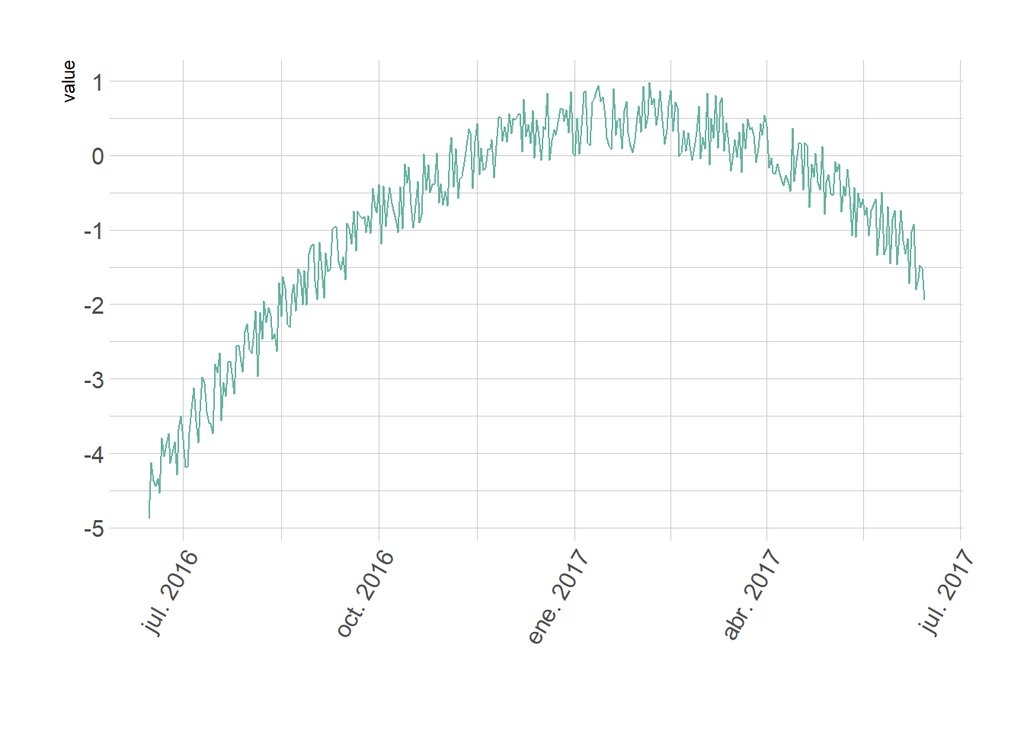

```r
library(ggplot2)
library(dplyr)
library(hrbrthemes)

# Dummy data
data <- data.frame(
  day = as.Date("2017-06-14") - 0:364,
  value = runif(365) - seq(-140, 224)^2 / 10000
)

# Most basic bubble plot
p <- ggplot(data, aes(x=day, y=value)) +
  geom_line( color="#69b3a2") +
  xlab("") +
  theme_ipsum() +
  theme(axis.text.x=element_text(angle=60, hjust=1))

p
```

### Mapas

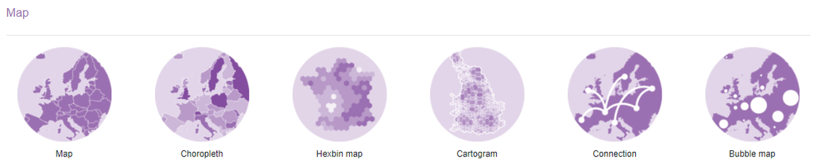

R es conocido y preferido sobre todo por sus mapas…

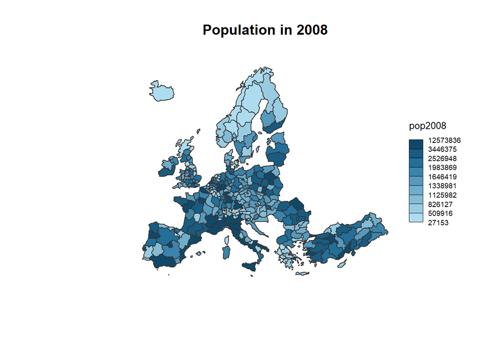

```r
# Use the cartography library to do the choropleth map
library(cartography)

# Load data
data(nuts2006)

# Build a choropleth
choroLayer(spdf = nuts2.spdf, df = nuts2.df, var = "pop2008" , legend.pos = "right")
title("Population in 2008")
```

### Flow

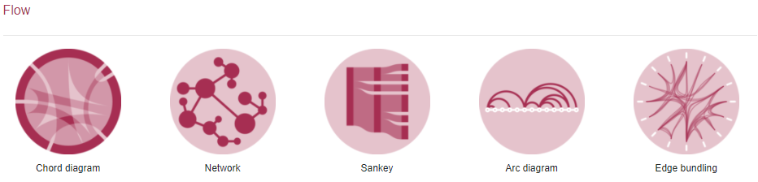

Veamos algunos ejemplos de flujos:

##### Network

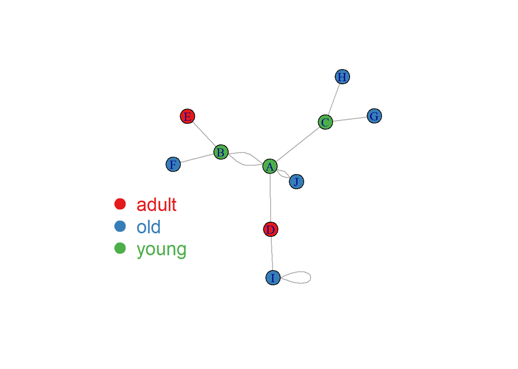

```r
library(igraph)
# create data:
links <- data.frame(
    source=c("A","A", "A", "A", "A","J", "B", "B", "C", "C", "D","I"),
    target=c("B","B", "C", "D", "J","A","E", "F", "G", "H", "I","I"),
    importance=(sample(1:4, 12, replace=T))
    )
nodes <- data.frame(
    name=LETTERS[1:10],
    carac=c( rep("young",3),rep("adult",2), rep("old",5))
    )

# Turn it into igraph object
network <- graph_from_data_frame(d=links, vertices=nodes, directed=F)

# Make a palette of 3 colors
library(RColorBrewer)
coul  <- brewer.pal(3, "Set1")

# Create a vector of color
my_color <- coul[as.numeric(as.factor(V(network)$carac))]

# Make the plot
plot(network, vertex.color=my_color)

# Add a legend
legend("bottomleft", legend=levels(as.factor(V(network)$carac))  , col = coul , bty = "n", pch=20 , pt.cex = 3, cex = 1.5, text.col=coul , horiz = FALSE, inset = c(0.1, 0.1))
```

##### Diagrama Sankey

```r
library(tidyverse)
library(viridis)
library(patchwork)
library(hrbrthemes)
library(circlize)
```

```r
# Load dataset from github
data <- read.table("https://raw.githubusercontent.com/holtzy/data_to_viz/master/Example_dataset/13_AdjacencyDirectedWeighted.csv", header=TRUE)
# Package
library(networkD3)
# I need a long format
data_long <- data %>%
  rownames_to_column %>%
  gather(key = 'key', value = 'value', -rowname) %>%
  filter(value > 0)
colnames(data_long) <- c("source", "target", "value")
data_long$target <- paste(data_long$target, " ", sep="")

# From these flows we need to create a node data frame: it lists every entities involved in the flow
nodes <- data.frame(name=c(as.character(data_long$source), as.character(data_long$target)) %>% unique())

# With networkD3, connection must be provided using id, not using real name like in the links dataframe.. So we need to reformat it.
data_long$IDsource=match(data_long$source, nodes$name)-1
data_long$IDtarget=match(data_long$target, nodes$name)-1

# prepare colour scale
ColourScal ='d3.scaleOrdinal() .range(["#FDE725FF","#B4DE2CFF","#6DCD59FF","#35B779FF","#1F9E89FF","#26828EFF","#31688EFF","#3E4A89FF","#482878FF","#440154FF"])'

# Make the Network
sankeyNetwork(Links = data_long, Nodes = nodes,
                     Source = "IDsource", Target = "IDtarget",
                     Value = "value", NodeID = "name",
                     sinksRight=FALSE, colourScale=ColourScal, nodeWidth=40, fontSize=13, nodePadding=20)
```

[interactive chart not shown]

##### Diagrama chord

```r
# devtools::install_github("mattflor/chorddiag")
library(chorddiag)

# Create dummy data
m <- matrix(c(11975,  5871, 8916, 2868,
              1951, 10048, 2060, 6171,
              8010, 16145, 8090, 8045,
              1013,   990,  940, 6907),
            byrow = TRUE,
            nrow = 4, ncol = 4)

# A vector of 4 colors for 4 groups
haircolors <- c("black", "blonde", "brown", "red")
dimnames(m) <- list(have = haircolors,
                    prefer = haircolors)
groupColors <- c("#000000", "#FFDD89", "#957244", "#F26223")

# Build the chord diagram:
p <- chorddiag(m, groupColors = groupColors, groupnamePadding = 20)
p
```

[interactive chart not shown]

### Gráficos animados

¿Todo debe ser estático? NO!

Ver el siguiente enlace:

[Gráficos animados](https://www.r-graph-gallery.com/271-ggplot2-animated-gif-chart-with-gganimate.html)

### interactivos

¿Qué es un gráfico interactivo? También conocido como orientado a objetos.

Veamos un ejemplo:

[Gráficos interactivos](https://www.r-graph-gallery.com/338-interactive-circle-packing-with-circlepacker)

Realmente, la evolución de ggplot2 se llama “Plotly” y estos suelen ser gráficos interactivos. Los veremos más adelante, pero hay otras librerías que superan al a Plotly…

### 3D

Pues si, no puede mover de forma 3D un gráfico…

Ver el siguiente enlace:

[Gráficos 3D](https://www.r-graph-gallery.com/3d.html)

### Los denominados “arte”

Hay personas muy creativas que crean arte a partir de los gráficos.

Ver el siguiente enlace:

[Gráficos arte](https://www.data-to-art.com/)

## ggchart

[figure not shown]

## Plotly

[figure not shown]

## dygraph

[figure not shown]

## sunburstR

[figure not shown]

## highcharter

[figure not shown]

## REF

[figure not shown]

Véase los siguientes sitios de referencia

### lattice

https://www.statmethods.net/advgraphs/trellis.html http://www.sthda.com/english/wiki/lattice-graphs http://www.sthda.com/english/wiki/lattice-graphs https://www.rdocumentation.org/packages/lattice/versions/0.20-41 https://www.dummies.com/programming/r/how-to-create-a-lattice-plot-in-r/ https://data-flair.training/blogs/r-lattice-package/ https://stat.ethz.ch/R-manual/R-devel/library/lattice/html/Lattice.html http://www.datavis.ca/courses/RGraphics/R-Graphics3.pdf

### ggplot2

https://www.r-graph-gallery.com/ggplot2-package.html http://r-statistics.co/ggplot2-Tutorial-With-R.html https://ggplot2.tidyverse.org/ https://www.statmethods.net/advgraphs/ggplot2.html https://rpubs.com/daniballari/ggplot http://tutorials.iq.harvard.edu/R/Rgraphics/Rgraphics.html https://www.rdocumentation.org/packages/ggplot2/versions/3.3.2 https://swcarpentry.github.io/r-novice-gapminder-es/08-plot-ggplot2/ https://datacarpentry.org/R-ecology-lesson/04-visualization-ggplot2.html

### ggchart

https://github.com/thomas-neitmann/ggcharts https://www.rdocumentation.org/packages/ggcharts/versions/0.2.1 https://rdrr.io/cran/ggcharts/ https://tereom.github.io/tutoriales/R_intro_visualizacion.html

### Plotly

https://plotly.com/r/ https://plotly-r.com/ https://www.rdocumentation.org/packages/plotly/versions/4.9.2.1 https://www.neonscience.org/plotly https://www.it-swarm.dev/es/r-plotly/ https://github.com/ropensci/plotly https://rdrr.io/cran/plotly/man/ggplotly.html https://www.htmlwidgets.org/showcase_plotly.html https://www.r-bloggers.com/introduction-to-interactive-graphics-in-r-with-plotly/

### dygraph

https://rstudio.github.io/dygraphs/ https://www.htmlwidgets.org/showcase_dygraphs.html https://github.com/rstudio/dygraphs https://blog.rstudio.com/2015/04/14/interactive-time-series-with-dygraphs/ https://rdrr.io/cran/dygraphs/man/dySeries.html https://rpubs.com/Da_As_Kumi/561455 https://bookdown.org/kochiuyu/Technical-Analysis-with-R/dygraphs-package.html http://www.imsbio.co.jp/RGM/R_function_list?package=dygraphs&init=true https://www.r-bloggers.com/how-to-plot-with-dygraphs-exercises/

### sunburstR

http://rstudio-pubs-static.s3.amazonaws.com/495237_5336f47cb4df483f8f2780cd92066449.html https://www.data-to-viz.com/graph/sunburst.html https://github.com/timelyportfolio/sunburstR https://www.rdocumentation.org/packages/sunburstR/versions/2.1.3/topics/sunburst https://rdrr.io/cran/sunburstR/src/R/sunburst.R

### highcharter

https://rstudio-pubs-static.s3.amazonaws.com/320413_6ab300527e8548b1a3cbd0d4c6200fcc.html https://www.highcharts.com/blog/tutorials/highcharts-for-r-users/ https://towardsdatascience.com/exploring-highcharts-in-r-f754143efda7 https://github.com/jbkunst/highcharter https://www.htmlwidgets.org/showcase_highcharts.html https://rdrr.io/cran/highcharter/man/hc_legend.html https://rpubs.com/jbkunst/highcharter http://uribo.github.io/rpkg_showcase/graphics/highcharter.html